# BANA 7025 - Homework 3

Mark Hageman

11/8/2020

## Importing Data and Cleaning Data

*1. Import the data set using a Tidyverse function and NOT with a Base R function. How manyrows and columns are in the data set?*

```r
data <- read_csv('acs_2015_county_data_revised.csv',
                 col_names = T)
dim(data)
```

```
## [1] 3142   35
```

**There are 3142 rows and 35 columns in this data set.**

*2. Do any data types need changed? Show any code to change variable types and showcode/output for a `glimpse()` command after you’re finished.*

```r
str(data)
```

```
## tibble [3,142 x 35] (S3: spec_tbl_df/tbl_df/tbl/data.frame)
##  $ census_id     : num [1:3142] 1001 1003 1005 1007 1009 ...
##  $ state         : chr [1:3142] "Alabama" "Alabama" "Alabama" "Alabama" ...
##  $ county        : chr [1:3142] "Autauga" "Baldwin" "Barbour" "Bibb" ...
##  $ total_pop     : num [1:3142] 55221 195121 26932 22604 57710 ...
##  $ men           : num [1:3142] 26745 95314 14497 12073 28512 ...
##  $ women         : num [1:3142] 28476 99807 12435 10531 29198 ...
##  $ hispanic      : num [1:3142] 2.6 4.5 4.6 2.2 8.6 4.4 1.2 3.5 0.4 1.5 ...
##  $ white         : num [1:3142] 75.8 83.1 46.2 74.5 87.9 22.2 53.3 73 57.3 91.7 ...
##  $ black         : num [1:3142] 18.5 9.5 46.7 21.4 1.5 70.7 43.8 20.3 40.3 4.8 ...
##  $ native        : num [1:3142] 0.4 0.6 0.2 0.4 0.3 1.2 0.1 0.2 0.2 0.6 ...
##  $ asian         : num [1:3142] 1 0.7 0.4 0.1 0.1 0.2 0.4 0.9 0.8 0.3 ...
##  $ pacific       : num [1:3142] 0 0 0 0 0 0 0 0 0 0 ...
##  $ citizen       : num [1:3142] 40725 147695 20714 17495 42345 ...
##  $ income        : num [1:3142] 51281 50254 32964 38678 45813 ...
##  $ income_per_cap: num [1:3142] 24974 27317 16824 18431 20532 ...
##  $ poverty       : num [1:3142] 12.9 13.4 26.7 16.8 16.7 24.6 25.4 20.5 21.6 19.2 ...
##  $ child_poverty : num [1:3142] 18.6 19.2 45.3 27.9 27.2 38.4 39.2 31.6 37.2 30.1 ...
##  $ professional  : num [1:3142] 33.2 33.1 26.8 21.5 28.5 18.8 27.5 27.3 23.3 29.3 ...
##  $ service       : num [1:3142] 17 17.7 16.1 17.9 14.1 15 16.6 17.7 14.5 16 ...
##  $ office        : num [1:3142] 24.2 27.1 23.1 17.8 23.9 19.7 21.9 24.2 26.3 19.5 ...
##  $ construction  : num [1:3142] 8.6 10.8 10.8 19 13.5 20.1 10.3 10.5 11.5 13.7 ...
##  $ production    : num [1:3142] 17.1 11.2 23.1 23.7 19.9 26.4 23.7 20.4 24.4 21.5 ...
##  $ drive         : num [1:3142] 87.5 84.7 83.8 83.2 84.9 74.9 84.5 85.3 85.1 83.9 ...
##  $ carpool       : num [1:3142] 8.8 8.8 10.9 13.5 11.2 14.9 12.4 9.4 11.9 12.1 ...
##  $ transit       : num [1:3142] 0.1 0.1 0.4 0.5 0.4 0.7 0 0.2 0.2 0.2 ...
##  $ walk          : num [1:3142] 0.5 1 1.8 0.6 0.9 5 0.8 1.2 0.3 0.6 ...
##  $ other_transp  : num [1:3142] 1.3 1.4 1.5 1.5 0.4 1.7 0.6 1.2 0.4 0.7 ...
##  $ work_at_home  : num [1:3142] 1.8 3.9 1.6 0.7 2.3 2.8 1.7 2.7 2.1 2.5 ...
##  $ mean_commute  : num [1:3142] 26.5 26.4 24.1 28.8 34.9 27.5 24.6 24.1 25.1 27.4 ...
##  $ employed      : num [1:3142] 23986 85953 8597 8294 22189 ...
##  $ private_work  : num [1:3142] 73.6 81.5 71.8 76.8 82 79.5 77.4 74.1 85.1 73.1 ...
##  $ public_work   : num [1:3142] 20.9 12.3 20.8 16.1 13.5 15.1 16.2 20.8 12.1 18.5 ...
##  $ self_employed : num [1:3142] 5.5 5.8 7.3 6.7 4.2 5.4 6.2 5 2.8 7.9 ...
##  $ family_work   : num [1:3142] 0 0.4 0.1 0.4 0.4 0 0.2 0.1 0 0.5 ...
##  $ unemployment  : num [1:3142] 7.6 7.5 17.6 8.3 7.7 18 10.9 12.3 8.9 7.9 ...
##  - attr(*, "spec")=
##   .. cols(
##   ..   census_id = col_double(),
##   ..   state = col_character(),
```

[output cut: 19 more lines]

```
##   ..   production = col_double(),
##   ..   drive = col_double(),
##   ..   carpool = col_double(),
##   ..   transit = col_double(),
##   ..   walk = col_double(),
##   ..   other_transp = col_double(),
##   ..   work_at_home = col_double(),
##   ..   mean_commute = col_double(),
##   ..   employed = col_double(),
##   ..   private_work = col_double(),
##   ..   public_work = col_double(),
##   ..   self_employed = col_double(),
##   ..   family_work = col_double(),
##   ..   unemployment = col_double()
##   .. )
```

```r
glimpse(data)
```

```
## Rows: 3,142
## Columns: 35
## $ census_id      <dbl> 1001, 1003, 1005, 1007, 1009, 1011, 1013, 1015, 1017...
## $ state          <chr> "Alabama", "Alabama", "Alabama", "Alabama", "Alabama...
## $ county         <chr> "Autauga", "Baldwin", "Barbour", "Bibb", "Blount", "...
## $ total_pop      <dbl> 55221, 195121, 26932, 22604, 57710, 10678, 20354, 11...
## $ men            <dbl> 26745, 95314, 14497, 12073, 28512, 5660, 9502, 56274...
## $ women          <dbl> 28476, 99807, 12435, 10531, 29198, 5018, 10852, 6037...
## $ hispanic       <dbl> 2.6, 4.5, 4.6, 2.2, 8.6, 4.4, 1.2, 3.5, 0.4, 1.5, 7....
## $ white          <dbl> 75.8, 83.1, 46.2, 74.5, 87.9, 22.2, 53.3, 73.0, 57.3...
## $ black          <dbl> 18.5, 9.5, 46.7, 21.4, 1.5, 70.7, 43.8, 20.3, 40.3, ...
## $ native         <dbl> 0.4, 0.6, 0.2, 0.4, 0.3, 1.2, 0.1, 0.2, 0.2, 0.6, 0....
## $ asian          <dbl> 1.0, 0.7, 0.4, 0.1, 0.1, 0.2, 0.4, 0.9, 0.8, 0.3, 0....
## $ pacific        <dbl> 0.0, 0.0, 0.0, 0.0, 0.0, 0.0, 0.0, 0.0, 0.0, 0.0, 0....
## $ citizen        <dbl> 40725, 147695, 20714, 17495, 42345, 8057, 15581, 886...
```

[output cut: 22 more lines]

**There do not appear to be any data types that need to be changed. The columns are all either character or numeric types, and each column appears to be typed appropriately.**

*3. Are there any missing values? How will you handle missing values? Will you impute a missingvalue with, for example, a mean or median value for the entire column, or will you remove the entire observation? Give a rationale for your decision and show any code/output to handle missing values.*

```r
# find count of na values in each column
colSums(is.na(data))
```

```
##      census_id          state         county      total_pop            men
##              0              0              0              0              0
##          women       hispanic          white          black         native
##              0              0              0              0              0
##          asian        pacific        citizen         income income_per_cap
##              0              0              0              1              0
##        poverty  child_poverty   professional        service         office
##              0              1              0              0              0
##   construction     production          drive        carpool        transit
##              0              0              0              0              0
##           walk   other_transp   work_at_home   mean_commute       employed
##              0              0              0              0              0
##   private_work    public_work  self_employed    family_work   unemployment
##              0              0              0              0              0
```

```r
# locate record with na income
data[is.na(data$income), c('state', 'county', 'income')]
```

```
## # A tibble: 1 x 3
##   state county income
##   <chr> <chr>   <dbl>
## 1 Texas Loving     NA
```

```r
# impute median for income
(median_income <- median(data$income, na.rm = T))
```

```
## [1] 45111
```

```r
data <- data %>%
  mutate(income = replace_na(income, median_income))

# locate record with na child_poverty
data[is.na(data$child_poverty), c('state', 'county', 'child_poverty')]
```

```
## # A tibble: 1 x 3
##   state  county  child_poverty
##   <chr>  <chr>           <dbl>
## 1 Hawaii Kalawao            NA
```

```r
# impute mean for child_poverty
(mean_child_poverty <- mean(data$child_poverty, na.rm = T))
```

```
## [1] 23.28609
```

```r
data <- data %>%
  mutate(child_poverty = replace_na(child_poverty, mean_child_poverty))
colSums(is.na(data))
```

```
##      census_id          state         county      total_pop            men
##              0              0              0              0              0
##          women       hispanic          white          black         native
##              0              0              0              0              0
##          asian        pacific        citizen         income income_per_cap
##              0              0              0              0              0
##        poverty  child_poverty   professional        service         office
##              0              0              0              0              0
##   construction     production          drive        carpool        transit
##              0              0              0              0              0
##           walk   other_transp   work_at_home   mean_commute       employed
##              0              0              0              0              0
##   private_work    public_work  self_employed    family_work   unemployment
##              0              0              0              0              0
```

**One observation has an `na` value for the `income` field, and one observation has an `na` value for the `child_poverty` column. It makes sense to impute these values using the median value for the `income` field, and the mean value for the `child_poverty` field. While the actual values for these fields may be off from the imputed values, `income` and `child_poverty` will not play a significant role in our analysis, and by imputing these values we can retain the observations.**

*4. Use the `summary()` function to examine any unusual values. Are there any? If so, how will you handle these unusual values? Show any code/output to handle unusual values.*

```r
summary(data)
```

```
##    census_id        state              county            total_pop
##  Min.   : 1001   Length:3142        Length:3142        Min.   :      85
##  1st Qu.:18178   Class :character   Class :character   1st Qu.:   11028
##  Median :29176   Mode  :character   Mode  :character   Median :   25768
##  Mean   :30384                                         Mean   :  100737
##  3rd Qu.:45081                                         3rd Qu.:   67552
##  Max.   :56045                                         Max.   :10038388
##       men              women            hispanic          white
##  Min.   :     42   Min.   :     43   Min.   : 0.000   Min.   : 0.90
##  1st Qu.:   5546   1st Qu.:   5466   1st Qu.: 1.900   1st Qu.:65.60
##  Median :  12826   Median :  12907   Median : 3.700   Median :84.60
##  Mean   :  49565   Mean   :  51171   Mean   : 8.826   Mean   :77.28
##  3rd Qu.:  33319   3rd Qu.:  34122   3rd Qu.: 9.000   3rd Qu.:93.30
##  Max.   :4945351   Max.   :5093037   Max.   :98.700   Max.   :99.80
##      black            native           asian           pacific
##  Min.   : 0.000   Min.   : 0.000   Min.   : 0.000   Min.   : 0.00000
##  1st Qu.: 0.600   1st Qu.: 0.100   1st Qu.: 0.200   1st Qu.: 0.00000
##  Median : 2.100   Median : 0.300   Median : 0.500   Median : 0.00000
##  Mean   : 8.879   Mean   : 1.766   Mean   : 1.258   Mean   : 0.08475
##  3rd Qu.:10.175   3rd Qu.: 0.600   3rd Qu.: 1.200   3rd Qu.: 0.00000
##  Max.   :85.900   Max.   :92.100   Max.   :41.600   Max.   :35.30000
##     citizen            income       income_per_cap     poverty
##  Min.   :     80   Min.   : 19328   Min.   : 8292   Min.   : 1.4
##  1st Qu.:   8254   1st Qu.: 38826   1st Qu.:20471   1st Qu.:12.0
##  Median :  19434   Median : 45111   Median :23577   Median :16.0
##  Mean   :  70804   Mean   : 46830   Mean   :24338   Mean   :16.7
##  3rd Qu.:  50728   3rd Qu.: 52249   3rd Qu.:27138   3rd Qu.:20.3
##  Max.   :6046749   Max.   :123453   Max.   :65600   Max.   :53.3
##  child_poverty    professional      service          office
##  Min.   : 0.00   Min.   :13.50   Min.   : 5.00   Min.   : 4.10
##  1st Qu.:16.10   1st Qu.:26.70   1st Qu.:15.90   1st Qu.:20.20
##  Median :22.50   Median :30.00   Median :18.00   Median :22.40
##  Mean   :23.29   Mean   :31.04   Mean   :18.26   Mean   :22.13
##  3rd Qu.:29.48   3rd Qu.:34.40   3rd Qu.:20.20   3rd Qu.:24.30
##  Max.   :72.30   Max.   :74.00   Max.   :36.60   Max.   :35.40
##   construction     production        drive          carpool
##  Min.   : 1.70   Min.   : 0.00   Min.   : 5.20   Min.   : 0.00
##  1st Qu.: 9.80   1st Qu.:11.53   1st Qu.:76.60   1st Qu.: 8.50
##  Median :12.20   Median :15.40   Median :80.60   Median : 9.90
##  Mean   :12.74   Mean   :15.82   Mean   :79.08   Mean   :10.33
```

[output cut: 8 more lines]

```
##  Max.   :61.7000   Max.   :71.200   Max.   :39.100   Max.   :37.200
##   mean_commute      employed        private_work    public_work
##  Min.   : 4.90   Min.   :     62   Min.   :25.00   Min.   : 5.80
##  1st Qu.:19.30   1st Qu.:   4524   1st Qu.:70.90   1st Qu.:13.10
##  Median :22.90   Median :  10644   Median :75.80   Median :16.10
##  Mean   :23.15   Mean   :  46387   Mean   :74.44   Mean   :17.35
##  3rd Qu.:26.60   3rd Qu.:  29254   3rd Qu.:79.80   3rd Qu.:20.10
##  Max.   :44.00   Max.   :4635465   Max.   :88.30   Max.   :66.20
##  self_employed     family_work      unemployment
##  Min.   : 0.000   Min.   :0.0000   Min.   : 0.000
##  1st Qu.: 5.400   1st Qu.:0.1000   1st Qu.: 5.500
##  Median : 6.900   Median :0.2000   Median : 7.500
##  Mean   : 7.921   Mean   :0.2915   Mean   : 7.815
##  3rd Qu.: 9.400   3rd Qu.:0.3000   3rd Qu.: 9.700
##  Max.   :36.600   Max.   :9.8000   Max.   :29.400
```

```r
data[which.max(data$hispanic), c('census_id', 'state', 'county', 'hispanic')]
```

```
## # A tibble: 1 x 4
##   census_id state county hispanic
##       <dbl> <chr> <chr>     <dbl>
## 1     48427 Texas Starr      98.7
```

**There do not appear to be any unusual values based on the summaries for each column. At first, the value of `hispanic` for Starr County, Texas appears as if it might be unusually high, but a quick search of [wikipedia.org](https://www.wikipedia.org/) reveals that, in fact, Starr County was about 95% Hispanic as of the 2010 U.S. census.**

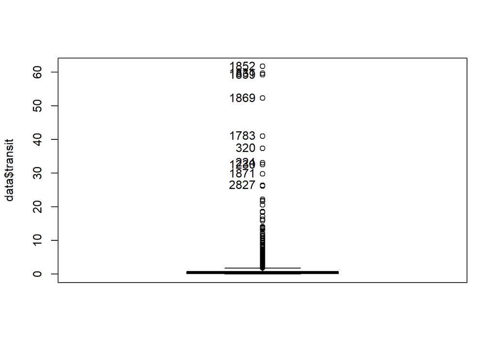

```
##  [1] 1852 1831 1859 1869 1783  320  224 1230 1871 2827
```

```r
Boxplot(data$transit)
```

```r
data[which.max(data$transit), c('census_id', 'state', 'county', 'transit')]
```

```
## # A tibble: 1 x 4
##   census_id state    county transit
##       <dbl> <chr>    <chr>    <dbl>
## 1     36047 New York Kings     61.7
```

**The maximum value of `transit` appears unusually high, but when we realize that Kings County, New York is the borough of Brooklyn in New York City, this value seems much more plausible.**

```r
data[which.max(data$child_poverty),
     c('census_id', 'state', 'county', 'child_poverty')]
```

```
## # A tibble: 1 x 4
##   census_id state        county   child_poverty
##       <dbl> <chr>        <chr>            <dbl>
## 1     46095 South Dakota Mellette          72.3
```

```r
data[which.max(data$child_poverty),
     c('census_id', 'state', 'county', 'poverty')]
```

```
## # A tibble: 1 x 4
##   census_id state        county   poverty
##       <dbl> <chr>        <chr>      <dbl>
## 1     46095 South Dakota Mellette    45.3
```

**Another possibly inaccurate value appears in the `child-poverty` column, but when we investigate a little further, we see that the same county (Merlette County in South Dakota) has a high value for `poverty`, indicating that the value for `child_poverty` is not an error.**

**The conclusion, therefore, is that there are no inappropriately unusual values in the data set, so no changes are necessary.**

## Data Manipulation and Insights

*5. How many counties have more women than men?*

```r
nrow(data[data$men < data$women, ])
```

```
## [1] 1985
```

**There are 1985 counties that have more women than men.**

*6. How many counties have an unemployment rate lower than 10%?*

```r
nrow(data[data$unemployment < .1,])
```

```
## [1] 4
```

*7. What are the top 10 counties with the highest mean commute? Show the census ID, countyname, state, and the mean_commute in your final answer (sorted by mean_commute).*

```r
data %>%
  arrange(desc(mean_commute)) %>%
  slice_head(n = 10) %>%
  select(census_id, county, state, mean_commute)
```

```
## # A tibble: 10 x 4
##    census_id county       state         mean_commute
##        <dbl> <chr>        <chr>                <dbl>
##  1     42103 Pike         Pennsylvania          44
##  2     36005 Bronx        New York              43
##  3     24017 Charles      Maryland              42.8
##  4     51187 Warren       Virginia              42.7
##  5     36081 Queens       New York              42.6
##  6     36085 Richmond     New York              42.6
##  7     51193 Westmoreland Virginia              42.5
##  8      8093 Park         Colorado              42.4
##  9     36047 Kings        New York              41.7
## 10     54015 Clay         West Virginia         41.4
```

*8. Create a new variable that calculates the percentage of women for each county and then findthe top 10 counties with the lowest percentages. Show the census ID, county name, state,and the percentage in your final answer (sorted by ascending percentage).*

```r
data %>%
  mutate(pct_women = women / total_pop) %>%
  arrange(pct_women) %>%
  select(census_id, county, state, pct_women)
```

```
## # A tibble: 3,142 x 4
##    census_id county                 state        pct_women
##        <dbl> <chr>                  <chr>            <dbl>
##  1     42053 Forest                 Pennsylvania     0.268
##  2      8011 Bent                   Colorado         0.314
##  3     51183 Sussex                 Virginia         0.315
##  4     13309 Wheeler                Georgia          0.321
##  5      6035 Lassen                 California       0.332
##  6     48095 Concho                 Texas            0.333
##  7     13053 Chattahoochee          Georgia          0.334
##  8      2013 Aleutians East Borough Alaska           0.335
##  9     22125 West Feliciana         Louisiana        0.336
## 10     32027 Pershing               Nevada           0.337
## # ... with 3,132 more rows
```

*9. Create a new variable that calculates the sum of all race percentage variables (these columnsare the “hispanic”, “white”, “black”, “native”, “asian”, and “pacific” variables).*

- *a. What are the top 10 counties with the lowest sum of these race percentagevariables?*

```r
data <- data %>%
  mutate(
    sum_race_pct =
      round((hispanic + white + black + native + asian + pacific), 2)
  )
data %>%
  arrange(sum_race_pct) %>%
  slice_head(n = 10) %>%
  select(county, state, sum_race_pct)
```

```
## # A tibble: 10 x 3
##    county                   state     sum_race_pct
##    <chr>                    <chr>            <dbl>
##  1 Hawaii                   Hawaii            76.4
##  2 Maui                     Hawaii            79.2
##  3 Mayes                    Oklahoma          79.7
##  4 Honolulu                 Hawaii            81.5
##  5 Pontotoc                 Oklahoma          82.8
##  6 Grundy                   Tennessee         83
##  7 Yakutat City and Borough Alaska            83.4
##  8 Johnston                 Oklahoma          84
##  9 Kauai                    Hawaii            84.1
## 10 Alfalfa                  Oklahoma          85.1
```

- *b. Which state, on average, has the lowest sum of these race percentage variables?*

```r
by_state <- group_by(data, state)
summarize(by_state, avg_race_pct = mean(sum_race_pct)) %>%
  arrange(avg_race_pct) %>%
  slice_head(n = 1)
```

```
## # A tibble: 1 x 2
##   state  avg_race_pct
##   <chr>         <dbl>
## 1 Hawaii           84
```

- *c. Do any counties have a sum greater than 100%?*

```r
nrow(subset(data, data$sum_race_pct > 100))
```

```
## [1] 5
```

```r
data %>%
  filter(sum_race_pct > 100) %>%
  select(state, county, sum_race_pct) %>%
  arrange(county)
```

```
## # A tibble: 5 x 3
##   state    county  sum_race_pct
##   <chr>    <chr>          <dbl>
## 1 Texas    Bailey          100.
## 2 Texas    Edwards         100.
## 3 Nebraska Gosper          100.
## 4 Nebraska Hooker          100.
## 5 Nebraska Nance           100.
```

**There are 5 counties that have a sum greater than 100.**

- *d. How many states have a sum that equals exactly to 100%?*

```r
nrow(subset(data, data$sum_race_pct == 100.0))
```

```
## [1] 38
```

```r
data %>%
  filter(sum_race_pct == 100.0) %>%
  select(state, county, sum_race_pct) %>%
  arrange(county)
```

```
## # A tibble: 38 x 3
##    state        county    sum_race_pct
##    <chr>        <chr>            <dbl>
##  1 Utah         Beaver             100
##  2 Texas        Brooks             100
##  3 Kentucky     Butler             100
##  4 Mississippi  Claiborne          100
##  5 Montana      Daniels            100
##  6 Texas        Dimmit             100
##  7 Texas        Duval              100
##  8 Nevada       Eureka             100
##  9 South Dakota Faulk              100
## 10 Oregon       Gilliam            100
## # ... with 28 more rows
```

**38 counties have a sum that is equal to 100%.**

*10. Using the carpool variable,*

- *a. Use the `dplyr::min_rank()` function to create a new variable called carpool_rank where the highest ranked county (rank = 1) is the county with the highest carpool value. Read the documentation carefully for the ranking function.*

```r
data <- data %>%
  mutate(carpool_rank = min_rank(desc(data$carpool)))
```

- *b. Find the 10 highest ranked counties for carpooling. Show the census ID, countyname, state, carpool value, and carpool_rank in your final answer.*

```r
data %>%
  arrange(carpool_rank) %>%
  slice_head(n = 10) %>%
  select(census_id, county, state, carpool, carpool_rank)
```

```
## # A tibble: 10 x 5
##    census_id county   state    carpool carpool_rank
##        <dbl> <chr>    <chr>      <dbl>        <int>
##  1     13061 Clay     Georgia     29.9            1
##  2     18087 LaGrange Indiana     27              2
##  3     13165 Jenkins  Georgia     25.3            3
##  4      5133 Sevier   Arkansas    24.4            4
##  5     20175 Seward   Kansas      23.4            5
##  6     48079 Cochran  Texas       22.8            6
##  7     48247 Jim Hogg Texas       22.6            7
##  8     48393 Roberts  Texas       22.4            8
##  9     39075 Holmes   Ohio        21.8            9
## 10     21197 Powell   Kentucky    21.6           10
```

- *c. Find the 10 lowest ranked counties for carpooling. Show the same variables in yourfinal answer.*

```r
data %>%
  arrange(desc(carpool_rank)) %>%
  slice_head(n = 10) %>%
  select(census_id, county, state, carpool, carpool_rank)
```

```
## # A tibble: 10 x 5
##    census_id county   state        carpool carpool_rank
##        <dbl> <chr>    <chr>          <dbl>        <int>
##  1     48261 Kenedy   Texas            0           3141
##  2     48269 King     Texas            0           3141
##  3     48235 Irion    Texas            0.9         3140
##  4     31183 Wheeler  Nebraska         1.3         3139
##  5     36061 New York New York         1.9         3138
##  6     13309 Wheeler  Georgia          2.3         3136
##  7     38029 Emmons   North Dakota     2.3         3136
##  8     30019 Daniels  Montana          2.6         3134
##  9     31057 Dundy    Nebraska         2.6         3134
## 10     46069 Hyde     South Dakota     2.8         3132
```

- *d. On average, what state is the best ranked for carpooling?*

```r
data %>%
  group_by(state) %>%
  summarize(avg_carpool = mean(carpool)) %>%
  arrange(desc(avg_carpool)) %>%
  slice_head(n = 1)
```

```
## # A tibble: 1 x 2
##   state  avg_carpool
##   <chr>        <dbl>
## 1 Alaska        12.1
```

- *e. What are the top 5 states for carpooling?*

```r
data %>%
  group_by(state) %>%
  summarize(avg_carpool = mean(carpool)) %>%
  arrange(desc(avg_carpool)) %>%
  slice_head(n = 5)
```

```
## # A tibble: 5 x 2
##   state    avg_carpool
##   <chr>          <dbl>
## 1 Alaska          12.1
## 2 Arkansas        11.9
## 3 Utah            11.9
## 4 Texas           11.8
## 5 Nevada          11.7
```